# Statistical Analysis Report

Biochemical Assesment of serum Calcium, Albumin and Phosphatase in malaria-Infected and non-infected children

Abdul Baasit Ismail CEO Achiver analyst

# 1 Introduction

This report provides a statistical analysis of serum calcium, albumin, and phosphate concentrations in malaria-infected and non-infected children. The analysis follows three specific objectives:

1. Assess the serum levels of calcium, albumin, and phosphate in malaria-infected and non-infected children.
2. Compare biochemical parameters across malaria and control groups.
3. Determine correlations among parameters within malaria-infected children.

All analyses were performed in **R**, and the steps are detailed below.

# 2 Data Cleaning and Preparation

```r
library(rio) # for data importation
library(tidyverse) # for data wragling

#importing the dataset
owo <- import("C:/Users/user/Downloads/ola.xlsx")
glimpse(owo)
```

```
## Rows: 386
## Columns: 6
## $ `S/N`                <dbl> 1, 2, 3, 4, 5, 6, 7, 8, 9, 10, 11, 12, 13, 14, 15…
## $ `SAMPLE NUMBER`      <chr> "STD", "SAMPLE 001", "SAMPLE 002", "SAMPLE 003", …
## $ AGE                  <dbl> NA, 3.0, 6.0, 12.0, 12.0, 12.0, 6.0, 7.0, 9.0, 4.…
## $ `CALCIUM (mmol/L)`   <dbl> 2.5, 2.6, 2.3, 2.4, 2.4, 2.2, 2.3, 2.4, 2.3, 2.4,…
## $ `ALBUMIN (g/L)`      <dbl> 40, 31, 40, 38, 39, 37, 39, 41, 39, 41, 39, 40, 4…
## $ `PHOSPHATE (mmol/L)` <dbl> 1.6, 1.1, 0.7, 0.8, 0.8, 1.2, 1.3, 0.6, 0.8, 0.9,…
```

```r
owo <- owo |>
  select(!`S/N`) # ro drop s/n

# data cleaning
owo <- owo |>
  filter(!(is.na(`SAMPLE NUMBER`) |
             `SAMPLE NUMBER` == ""))
colnames(owo) <- c('sampleId', 'age', 'calcium', 'albumin', 'phosphatase')
View(owo)

# identify and inspect all unique labels in sampleId
unique(owo$sampleId)
```

[output not shown]

[output cut: 62 more lines]

```r
# create a new variable (status)
owo$status <- case_when(
  grepl('CONTROL', owo$sampleId, ignore.case = T) ~ 'control', #for control
  grepl('SAMPLE', owo$sampleId, ignore.case = T) ~ 'malaria',  #for malaria
  TRUE ~ NA_character_
)

# remove std and na
owo <- owo |>
  filter(!is.na(status))
glimpse(owo)
```

```
## Rows: 381
## Columns: 6
## $ sampleId    <chr> "SAMPLE 001", "SAMPLE 002", "SAMPLE 003", "SAMPLE 004", "S…
## $ age         <dbl> 3.0, 6.0, 12.0, 12.0, 12.0, 6.0, 7.0, 9.0, 4.0, 12.0, 2.0,…
## $ calcium     <dbl> 2.6, 2.3, 2.4, 2.4, 2.2, 2.3, 2.4, 2.3, 2.4, 2.4, 2.2, 2.3…
## $ albumin     <dbl> 31, 40, 38, 39, 37, 39, 41, 39, 41, 39, 40, 40, 41, 41, 40…
## $ phosphatase <dbl> 1.1, 0.7, 0.8, 0.8, 1.2, 1.3, 0.6, 0.8, 0.9, 0.3, 0.3, 0.5…
## $ status      <chr> "malaria", "malaria", "malaria", "malaria", "malaria", "ma…
```

```r
#summary data
summary(owo)
```

```
##    sampleId              age            calcium         albumin
##  Length:381         Min.   : 1.000   Min.   :1.400   Min.   :31.00
##  Class :character   1st Qu.: 3.000   1st Qu.:2.000   1st Qu.:39.00
##  Mode  :character   Median : 5.000   Median :2.300   Median :40.00
##                     Mean   : 5.936   Mean   :2.283   Mean   :40.17
##                     3rd Qu.: 9.000   3rd Qu.:2.400   3rd Qu.:42.00
##                     Max.   :12.000   Max.   :3.400   Max.   :46.00
##   phosphatase       status
##  Min.   :0.300   Length:381
##  1st Qu.:0.800   Class :character
##  Median :0.900   Mode  :character
##  Mean   :1.032
##  3rd Qu.:1.300
##  Max.   :1.900
```

```r
table(owo$status)
```

```
##
## control malaria
##     100     281
```

# 3 Descriptive and Comparative Statistics

Descriptive statistics were generated to summarize calcium, albumin, and phosphate levels within each group.

```r
# statistical analysis
#statistical summary.
tapply(owo$calcium, owo$status, summary)
```

```
## $control
##    Min. 1st Qu.  Median    Mean 3rd Qu.    Max.
##   1.900   2.000   2.100   2.101   2.200   2.600
##
## $malaria
##    Min. 1st Qu.  Median    Mean 3rd Qu.    Max.
##   1.400   2.200   2.400   2.348   2.600   3.400
```

```r
tapply(owo$albumin, owo$status, summary)
```

```
## $control
##    Min. 1st Qu.  Median    Mean 3rd Qu.    Max.
##   37.00   40.00   41.00   40.93   42.00   46.00
##
## $malaria
##    Min. 1st Qu.  Median    Mean 3rd Qu.    Max.
##    31.0    38.0    40.0    39.9    42.0    46.0
```

```r
tapply(owo$phosphatase, owo$status, summary)
```

```
## $control
##    Min. 1st Qu.  Median    Mean 3rd Qu.    Max.
##   0.800   1.000   1.200   1.168   1.300   1.700
##
## $malaria
##    Min. 1st Qu.  Median    Mean 3rd Qu.    Max.
##  0.3000  0.8000  0.9000  0.9833  1.2000  1.9000
```

```r
tapply(owo$age, owo$status, summary)
```

```
## $control
##    Min. 1st Qu.  Median    Mean 3rd Qu.    Max.
##    1.00    3.00    5.00    5.39    8.00   12.00
##
## $malaria
##    Min. 1st Qu.  Median    Mean 3rd Qu.    Max.
##    1.00    3.00    6.00    6.13    9.00   12.00
```

```r
# compare parameters across the two status
# using independent t-test
calcium <- t.test(calcium ~ status, data = owo) # for calcium
albumin <- t.test(albumin ~ status, data = owo) # for albumin
phosphatase <- t.test(phosphatase ~ status, data = owo) # for phosphatase

calcium
```

```
##
##  Welch Two Sample t-test
##
## data:  calcium by status
## t = -9.7875, df = 342.66, p-value < 2.2e-16
## alternative hypothesis: true difference in means between group control and group malaria is not equal to 0
## 95 percent confidence interval:
##  -0.2966890 -0.1973964
## sample estimates:
## mean in group control mean in group malaria
##              2.101000              2.348043
```

```r
albumin
```

```
##
##  Welch Two Sample t-test
##
## data:  albumin by status
## t = 4.2463, df = 224.22, p-value = 3.185e-05
## alternative hypothesis: true difference in means between group control and group malaria is not equal to 0
## 95 percent confidence interval:
##  0.5518113 1.5074770
## sample estimates:
## mean in group control mean in group malaria
##              40.93000              39.90036
```

```r
phosphatase
```

```
##
##  Welch Two Sample t-test
##
## data:  phosphatase by status
## t = 5.8696, df = 288.29, p-value = 1.199e-08
## alternative hypothesis: true difference in means between group control and group malaria is not equal to 0
## 95 percent confidence interval:
##  0.1227823 0.2466697
## sample estimates:
## mean in group control mean in group malaria
##              1.168000              0.983274
```

# 4 Correlation Analysis by Malaria infected children only

```r
# objective three
# correlate among biochemical parameters in malaria children
# filter malaria children only
malaria <- owo |>
  filter(status == 'malaria')
View(malaria)

# correlations
cor_calcium_albumin <- cor.test(malaria$calcium, malaria$albumin)
cor_calcium_phosphate <- cor.test(malaria$calcium, malaria$phosphatase)
cor_albumin_phosphate <- cor.test(malaria$albumin, malaria$phosphatase)

cor_calcium_albumin
```

```
##
##  Pearson's product-moment correlation
##
## data:  malaria$calcium and malaria$albumin
## t = 0.20916, df = 279, p-value = 0.8345
## alternative hypothesis: true correlation is not equal to 0
## 95 percent confidence interval:
##  -0.1046448  0.1293437
## sample estimates:
##        cor
## 0.01252083
```

```r
cor_calcium_phosphate
```

```
##
##  Pearson's product-moment correlation
##
## data:  malaria$calcium and malaria$phosphatase
## t = 0.22494, df = 279, p-value = 0.8222
## alternative hypothesis: true correlation is not equal to 0
## 95 percent confidence interval:
##  -0.1037105  0.1302724
## sample estimates:
##       cor
## 0.0134653
```

```r
cor_albumin_phosphate
```

```
##
##  Pearson's product-moment correlation
##
## data:  malaria$albumin and malaria$phosphatase
## t = -0.26384, df = 279, p-value = 0.7921
## alternative hypothesis: true correlation is not equal to 0
## 95 percent confidence interval:
##  -0.1325612  0.1014059
## sample estimates:
##         cor
## -0.01579386
```

# 5 Visualizations

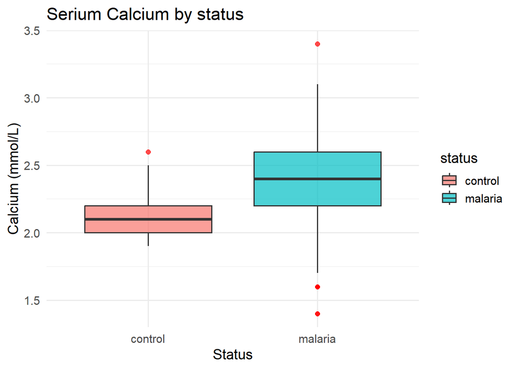

```r
# boxplots
ggplot(owo, aes(x = status, y = calcium, fill = status)) +
  geom_boxplot(alpha = 0.7, outlier.color = 'red') +
  labs(title = 'Serium Calcium by status', y = 'Calcium (mmol/L)', x = 'Status') +
  theme_minimal(base_size = 14) # calcium
```

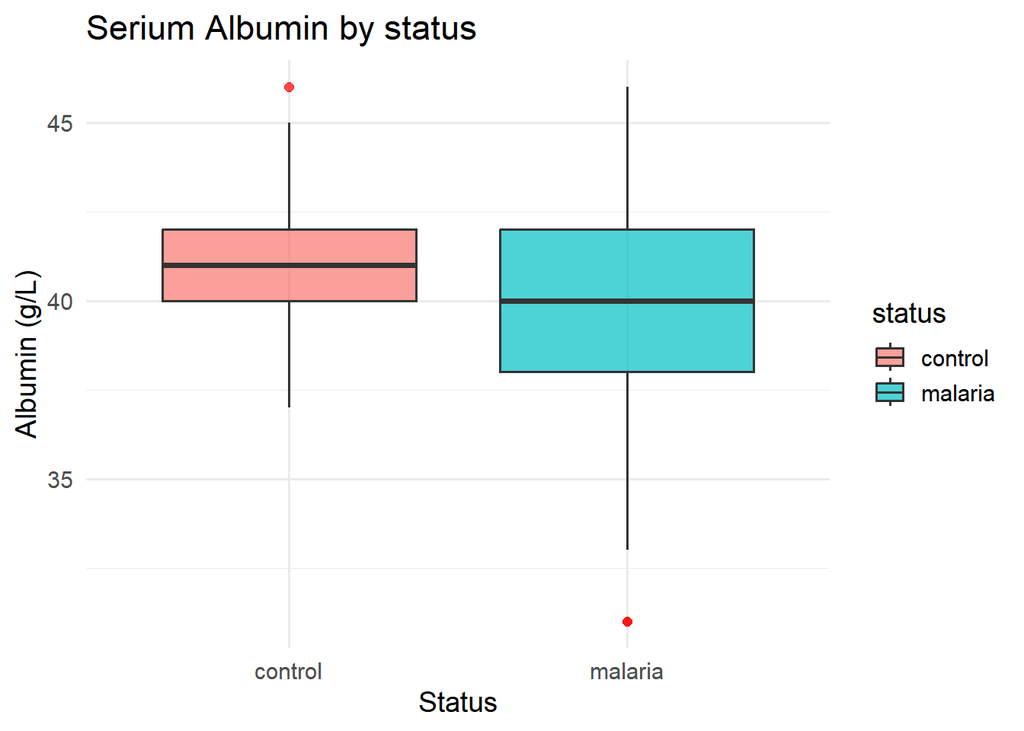

```r
ggplot(owo, aes(x = status, y = albumin, fill = status)) +
  geom_boxplot(alpha = 0.7, outlier.color = 'red') +
  labs(title = 'Serium Albumin by status', y = 'Albumin (g/L)', x = 'Status') +
  theme_minimal(base_size = 14)  # albumin
```

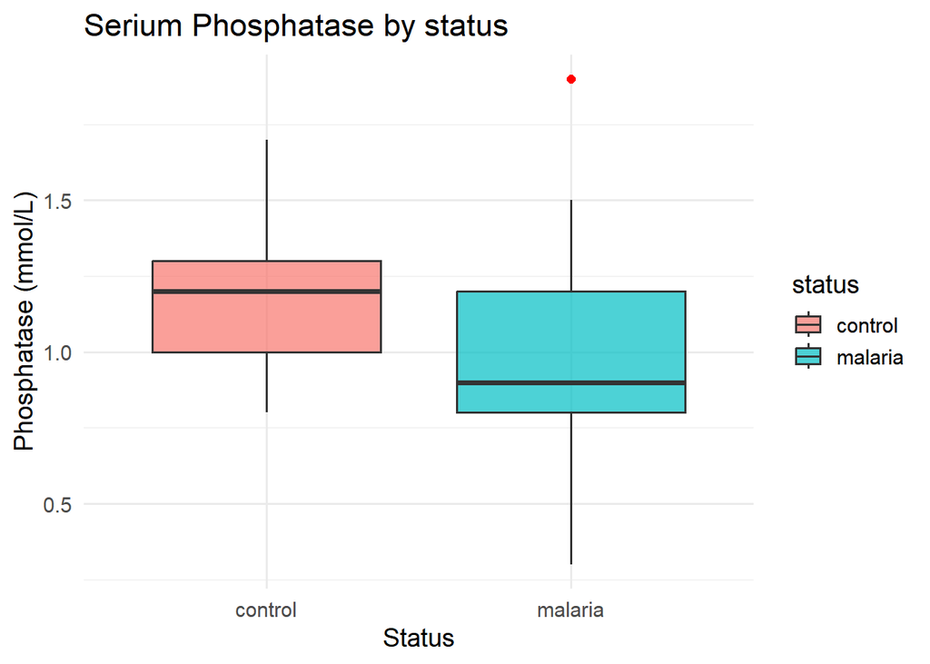

```r
ggplot(owo, aes(x = status, y = phosphatase, fill = status)) +
  geom_boxplot(alpha = 0.7, outlier.color = 'red') +
  labs(title = 'Serium Phosphatase by status', y = 'Phosphatase (mmol/L)', x = 'Status') +
  theme_minimal(base_size = 14) # phosphatase
```

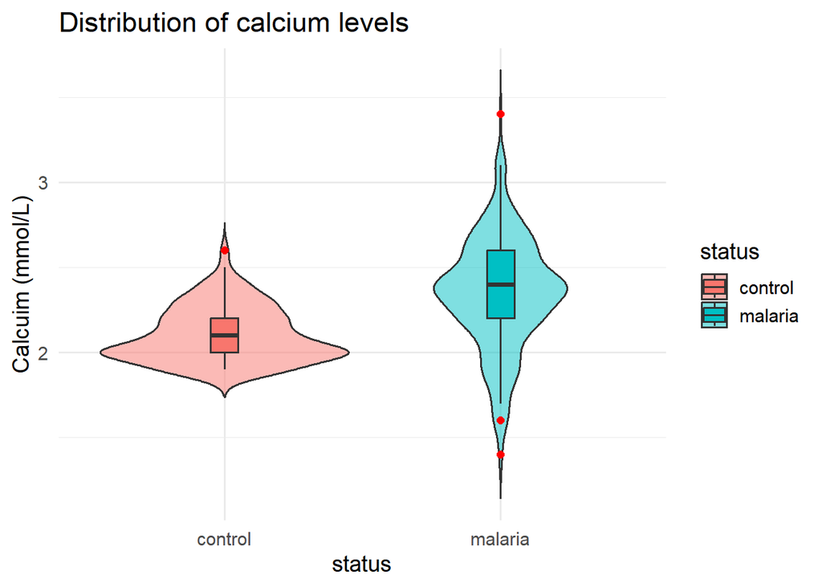

```r
# violin and boxplot
ggplot(owo, aes(status, calcium, fill = status)) +
  geom_violin(trim = F, alpha = 0.5) +
  geom_boxplot(width = 0.1, outlier.color = 'red') +
  labs(title = 'Distribution of calcium levels', y= 'Calcuim (mmol/L)') +
  theme_minimal(base_size = 14) # calcium
```

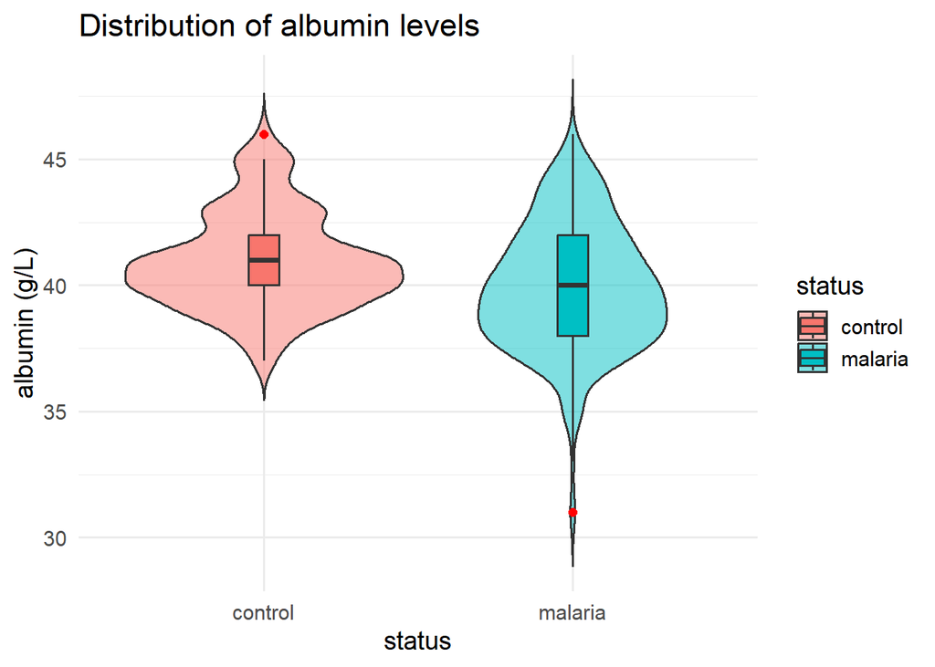

```r
ggplot(owo, aes(status, albumin, fill = status)) +
  geom_violin(trim = F, alpha = 0.5) +
  geom_boxplot(width = 0.1, outlier.color = 'red') +
  labs(title = 'Distribution of albumin levels', y= 'albumin (g/L)') +
  theme_minimal(base_size = 14) # albumin
```

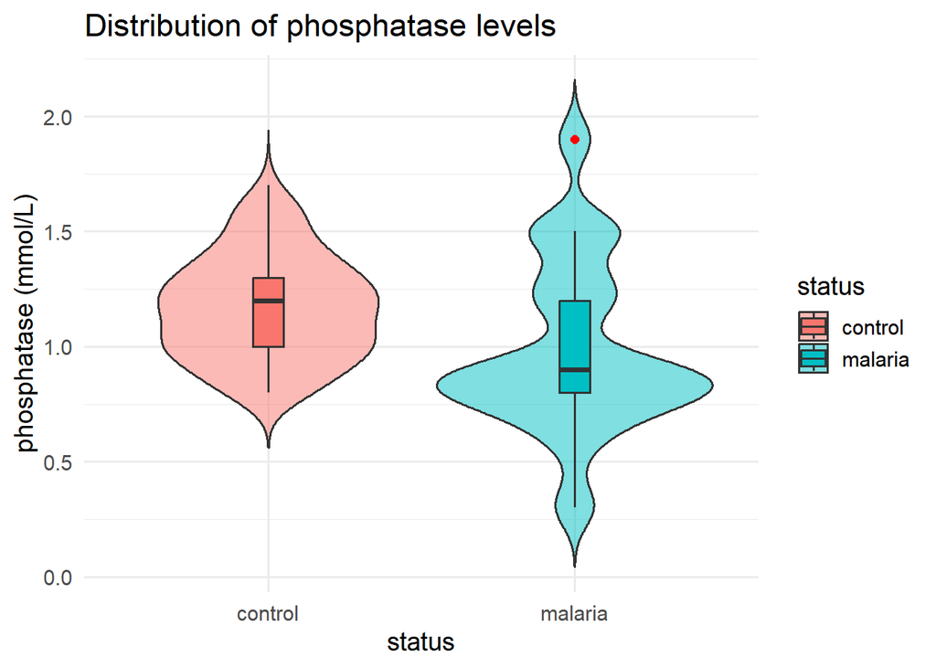

```r
ggplot(owo, aes(status, phosphatase, fill = status)) +
  geom_violin(trim = F, alpha = 0.5) +
  geom_boxplot(width = 0.1, outlier.color = 'red') +
  labs(title = 'Distribution of phosphatase levels', y= 'phosphatase (mmol/L)') +
  theme_minimal(base_size = 14) # phosphatase
```

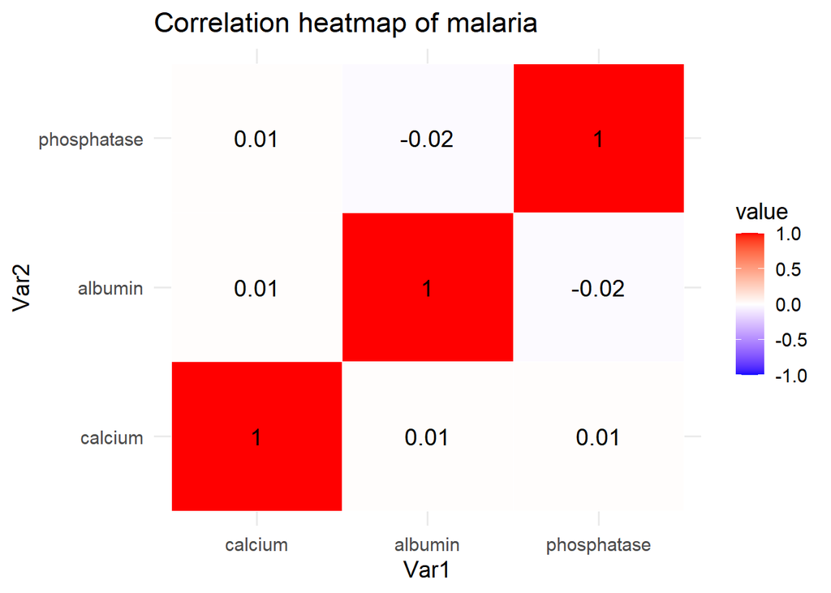

```r
# correlation heatmap malarian infected children only
library(reshape2)
corr_matrix <- round(cor(malaria[, c('calcium', 'albumin', 'phosphatase')],
                         use = 'complete.obs'), 2)
melt_corr <- melt(corr_matrix)

ggplot(melt_corr, aes(Var1, Var2, fill = value)) +
  geom_tile(color = 'white') +
  geom_text(aes(label = value), size = 5) +
  scale_fill_gradient2(low = 'blue', high = 'red', mid = 'white', midpoint = 0, limit = c(-1, 1)) +
  labs(title = 'Correlation heatmap of malaria') +
  theme_minimal(base_size = 14)
```

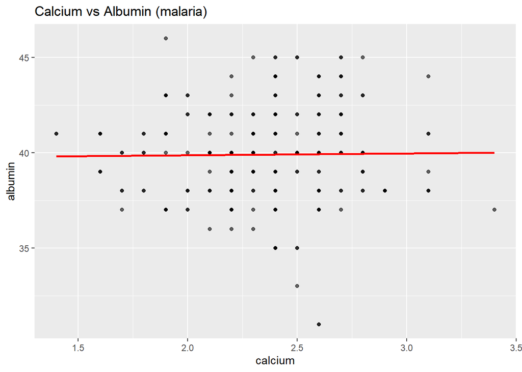

```r
# scatterplots
ggplot(malaria, aes(calcium, albumin)) +
  geom_point(alpha = 0.6) +
  geom_smooth(method = 'lm', se = F, color = 'red') +
  labs(title = 'Calcium vs Albumin (malaria)')
```

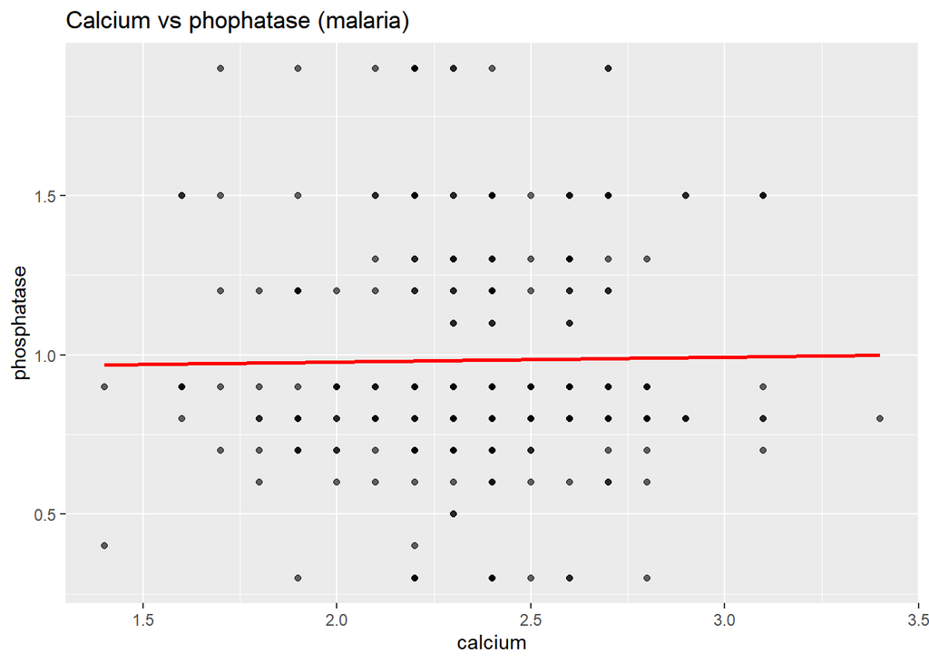

```r
ggplot(malaria, aes(calcium, phosphatase)) +
  geom_point(alpha = 0.6) +
  geom_smooth(method = 'lm', se = F, color = 'red') +
  labs(title = 'Calcium vs phophatase (malaria)')
```

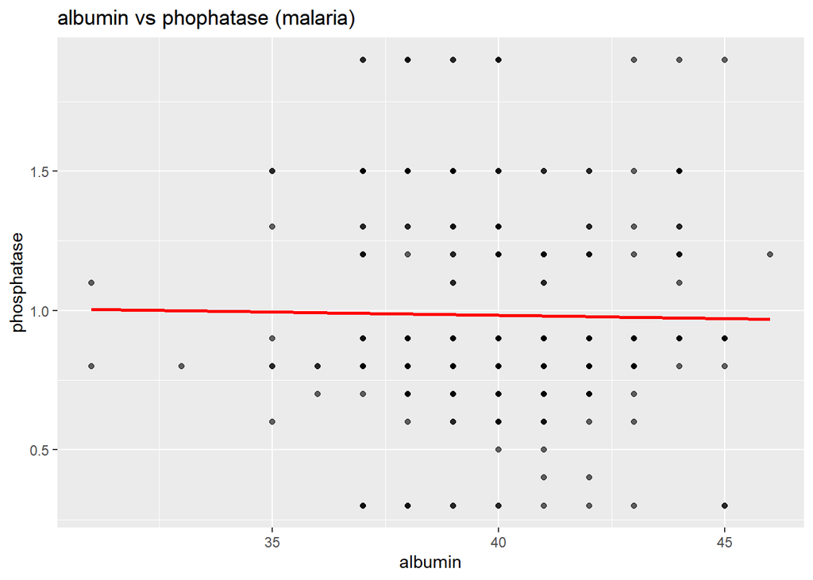

```r
ggplot(malaria, aes(albumin, phosphatase)) +
  geom_point(alpha = 0.6) +
  geom_smooth(method = 'lm', se = F, color = 'red') +
  labs(title = 'albumin vs phophatase (malaria)')
```

[figure not shown]

```r
# density plots
ggplot(owo, aes(calcium, status)) +
  geom_density(alpha = 0.5) +
  labs(title = 'Density Plot of Serium Calcium Levels') +
  theme_minimal(base_size = 14)
```

# 6 Conclusion

This analysis successfully:

Cleaned and standardized the dataset.

Computed descriptive statistics for biochemical markers.

Conducted group comparisons between malaria-infected and non-infected children.

Evaluated correlations among parameters within the malaria-infected group.

These results can now be used directly to write the Chapter Four (Results) of the project.

# 7 Appendix

Full dataset dimensions:

```r
dim(owo)
```

```
## [1] 381   6
```

```r
owo
```

[output not shown]

[output cut: 367 more lines]

```r
glimpse(owo)
```

```
## Rows: 381
## Columns: 6
## $ sampleId    <chr> "SAMPLE 001", "SAMPLE 002", "SAMPLE 003", "SAMPLE 004", "S…
## $ age         <dbl> 3.0, 6.0, 12.0, 12.0, 12.0, 6.0, 7.0, 9.0, 4.0, 12.0, 2.0,…
## $ calcium     <dbl> 2.6, 2.3, 2.4, 2.4, 2.2, 2.3, 2.4, 2.3, 2.4, 2.4, 2.2, 2.3…
## $ albumin     <dbl> 31, 40, 38, 39, 37, 39, 41, 39, 41, 39, 40, 40, 41, 41, 40…
## $ phosphatase <dbl> 1.1, 0.7, 0.8, 0.8, 1.2, 1.3, 0.6, 0.8, 0.9, 0.3, 0.3, 0.5…
## $ status      <chr> "malaria", "malaria", "malaria", "malaria", "malaria", "ma…
```

```r
str(owo)
```

```
## 'data.frame':    381 obs. of  6 variables:
##  $ sampleId   : chr  "SAMPLE 001" "SAMPLE 002" "SAMPLE 003" "SAMPLE 004" ...
##  $ age        : num  3 6 12 12 12 6 7 9 4 12 ...
##  $ calcium    : num  2.6 2.3 2.4 2.4 2.2 2.3 2.4 2.3 2.4 2.4 ...
##  $ albumin    : num  31 40 38 39 37 39 41 39 41 39 ...
##  $ phosphatase: num  1.1 0.7 0.8 0.8 1.2 1.3 0.6 0.8 0.9 0.3 ...
##  $ status     : chr  "malaria" "malaria" "malaria" "malaria" ...
```

```r
summary(owo)
```

```
##    sampleId              age            calcium         albumin
##  Length:381         Min.   : 1.000   Min.   :1.400   Min.   :31.00
##  Class :character   1st Qu.: 3.000   1st Qu.:2.000   1st Qu.:39.00
##  Mode  :character   Median : 5.000   Median :2.300   Median :40.00
##                     Mean   : 5.936   Mean   :2.283   Mean   :40.17
##                     3rd Qu.: 9.000   3rd Qu.:2.400   3rd Qu.:42.00
##                     Max.   :12.000   Max.   :3.400   Max.   :46.00
##   phosphatase       status
##  Min.   :0.300   Length:381
##  1st Qu.:0.800   Class :character
##  Median :0.900   Mode  :character
##  Mean   :1.032
##  3rd Qu.:1.300
##  Max.   :1.900
```

# 8 About me

Abdul-Baasit Ismail is a passionate Biochemistry and Molecular Biology student. Data Scientist and AI/ML Practitioner with strong experience in data cleaning, statistical analysis, predictive modelling, and applied machine learning. He works confidently with tools such as R, Python, SQL, and modern ML frameworks, delivering clean, reproducible analysis and data-driven insights.

He is particularly skilled at transforming raw, inconsistent datasets into meaningful patterns, building practical models, and communicating findings clearly through visualisations and reports. His work blends analytical rigour with creativity, enabling teams to make smarter, evidence-based decisions.

Abdul-Baasit is open to collaboration, research projects, internships, freelance roles, or data-driven problem-solving opportunities—especially in machine learning, AI applications, bioinformatics, health analytics, and data science automation.

If you’re looking for someone who combines technical depth, fast learning, and professional execution, you should definitely reach out.